# Lab: Data Manipulation Using Dplyr

Xuemao Zhang

June 25, 2019

## Introduction

- We cosider data manipulations using the package `dplyr` in this session
- Install the following packages if you don’t have them.

```
                install.packages('dplyr');
                install.packages('ggplot2');
                install.packages('gridExtra');
                install.packages('RColorBrewer');
```

- Weather forecast Accuracy Data: The data are measurements of forecasted and observed MinTemp (minimum temperature) and MaxTemp (maximum temperature) over one month period in 113 cities in US. There are three files.
- Locations file `locations.csv`: The 113 cities were fairly spread out and the observed weather data were measured in 113 airports. The `latitude` and `longitude` were used to get the airport code (AirPtCd).

```r
locations=read.csv("F:/DataCamp/data/locations.csv",header=TRUE, sep=",");
str(locations);
```

```
## 'data.frame':    113 obs. of  5 variables:
##  $ city     : Factor w/ 109 levels "Albany","Amarillo",..: 31 9 79 13 80 59 66 101 69 1 ...
##  $ state    : Factor w/ 50 levels "Alabama","Alaska",..: 19 19 19 21 39 29 45 21 7 32 ...
##  $ longitude: num  -67 -68.8 -70.2 -71.1 -71.4 ...
##  $ latitude : num  44.9 44.8 43.7 42.4 41.8 ...
##  $ AirPtCd  : Factor w/ 113 levels "KAAO","KACY",..: 14 13 89 22 87 69 74 24 57 4 ...
```

```r
head(locations);
```

```
##         city         state longitude latitude AirPtCd
## 1   Eastport         Maine  -66.9900  44.9100    KBHB
## 2     Bangor         Maine  -68.7833  44.8000    KBGR
## 3   Portland         Maine  -70.2500  43.6667    KPWM
## 4     Boston Massachusetts  -71.0833  42.3500    KBOS
## 5 Providence  Rhode Island  -71.4000  41.8333    KPVD
## 6 Manchester New Hampshire  -71.5000  43.0000    KMHT
```

- Weather forecast file `forecast201708.csv`:
  - `ID` is used to identify airports; there is a correspondenc between `ID` and `AirPtCd`.
  - `Date` is the date when weather data were measured and
  - `ForecastDate` is the date that the forecast was made on.
  - `Value_forecast` is the forecasted value.
  - `Variable_forecast` indicates what value is being forecast (MinTemp or MaxTemp)

```r
forecastWeather=read.csv("F:/DataCamp/data/forecast201708.csv",header=TRUE, sep=",");
str(forecastWeather);
```

```
## 'data.frame':    46468 obs. of  5 variables:
##  $ ID               : int  1 2 3 4 5 6 7 8 9 10 ...
##  $ Date             : Factor w/ 31 levels "8/1/2017","8/10/2017",..: 1 1 1 1 1 1 1 1 1 1 ...
##  $ Value_forecast   : int  72 82 78 84 84 84 80 85 82 84 ...
##  $ Variable_forecast: Factor w/ 2 levels "MaxTemp","MinTemp": 1 1 1 1 1 1 1 1 1 1 ...
##  $ ForecastDate     : Factor w/ 36 levels "7/26/2017","7/27/2017",..: 1 1 1 1 1 1 1 1 1 1 ...
```

```r
head(forecastWeather);
```

```
##   ID     Date Value_forecast Variable_forecast ForecastDate
## 1  1 8/1/2017             72           MaxTemp    7/26/2017
## 2  2 8/1/2017             82           MaxTemp    7/26/2017
## 3  3 8/1/2017             78           MaxTemp    7/26/2017
## 4  4 8/1/2017             84           MaxTemp    7/26/2017
## 5  5 8/1/2017             84           MaxTemp    7/26/2017
## 6  6 8/1/2017             84           MaxTemp    7/26/2017
```

- Historic measures of weather `histWeather201708.csv`:
  - `Date` is the date when weather data were measured which is variable in the file `forecast201708.csv`.
  - `Max_TemperatureF` is the measured MaxTemp.
  - `Mean_TemperatureF` is the measured average Temp.
  - `Min_TemperatureF` is the measured MinTemp.
  - `AirPtCd` is airport code and each airport is also identified by `ID`.

```r
library(dplyr);
```

```r
histWeather=read.csv("F:/DataCamp/data/histWeather201708.csv",header=TRUE, sep=","); #31 days weather data for 113 airports
dim(histWeather);
```

```
## [1] 3503    6
```

```r
str(histWeather);
```

```
## 'data.frame':    3503 obs. of  6 variables:
##  $ Date             : Factor w/ 31 levels "8/1/2017","8/10/2017",..: 1 12 23 26 27 28 29 30 31 2 ...
##  $ Max_TemperatureF : int  84 80 75 75 73 73 75 64 75 77 ...
##  $ Mean_TemperatureF: int  70 68 68 68 68 65 64 60 63 66 ...
##  $ Min_TemperatureF : int  55 57 60 60 62 57 54 57 51 55 ...
##  $ AirPtCd          : Factor w/ 113 levels "KAAO","KACY",..: 14 14 14 14 14 14 14 14 14 14 ...
##  $ ID               : int  1 1 1 1 1 1 1 1 1 1 ...
```

```r
head(histWeather);
```

```
##       Date Max_TemperatureF Mean_TemperatureF Min_TemperatureF AirPtCd ID
## 1 8/1/2017               84                70               55    KBHB  1
## 2 8/2/2017               80                68               57    KBHB  1
## 3 8/3/2017               75                68               60    KBHB  1
## 4 8/4/2017               75                68               60    KBHB  1
## 5 8/5/2017               73                68               62    KBHB  1
## 6 8/6/2017               73                65               57    KBHB  1
```

## Data Tidying

- There are three interrelated rules which make a dataset tidy:
  - Each variable must have its own column.
  - Each observation must have its own row.
  - Each value must have its own cell.
- The `forecastWeather` is not tidy.

```r
#add two variables: MinTemp_forecast,  MaxTemp_forecast
library(dplyr);
forecastWeather= mutate(forecastWeather, MinTemp_forecast=ifelse(Variable_forecast=='MinTemp', Value_forecast, NA));
forecastWeather= mutate(forecastWeather, MaxTemp_forecast=ifelse(Variable_forecast=='MaxTemp', Value_forecast, NA));
#then remove the two variables: Value_forecast, Variable_forecast
forecastWeather$Value_forecast=NULL;
forecastWeather$Variable_forecast=NULL;
str(forecastWeather);
```

```
## 'data.frame':    46468 obs. of  5 variables:
##  $ ID              : int  1 2 3 4 5 6 7 8 9 10 ...
##  $ Date            : Factor w/ 31 levels "8/1/2017","8/10/2017",..: 1 1 1 1 1 1 1 1 1 1 ...
##  $ ForecastDate    : Factor w/ 36 levels "7/26/2017","7/27/2017",..: 1 1 1 1 1 1 1 1 1 1 ...
##  $ MinTemp_forecast: int  NA NA NA NA NA NA NA NA NA NA ...
##  $ MaxTemp_forecast: int  72 82 78 84 84 84 80 85 82 84 ...
```

### Create two subdata sets for forecasted MinTemp and MaxTemp.

```r
forecast_MinTemp=select(forecastWeather, -c(MaxTemp_forecast));
forecast_MinTemp=filter(forecast_MinTemp, complete.cases(MinTemp_forecast) == T); #removing missing values
str(forecast_MinTemp);
```

```
## 'data.frame':    22780 obs. of  4 variables:
##  $ ID              : int  1 2 3 4 5 6 7 8 9 10 ...
##  $ Date            : Factor w/ 31 levels "8/1/2017","8/10/2017",..: 1 1 1 1 1 1 1 1 1 1 ...
##  $ ForecastDate    : Factor w/ 36 levels "7/26/2017","7/27/2017",..: 2 2 2 2 2 2 2 2 2 2 ...
##  $ MinTemp_forecast: int  56 60 63 67 65 62 58 64 68 64 ...
```

```r
head(forecast_MinTemp);
```

```
##   ID     Date ForecastDate MinTemp_forecast
## 1  1 8/1/2017    7/27/2017               56
## 2  2 8/1/2017    7/27/2017               60
## 3  3 8/1/2017    7/27/2017               63
## 4  4 8/1/2017    7/27/2017               67
## 5  5 8/1/2017    7/27/2017               65
## 6  6 8/1/2017    7/27/2017               62
```

```r
#remove the NAs
forecast_MaxTemp=select(forecastWeather, -c(MinTemp_forecast));
forecast_MaxTemp=filter(forecast_MaxTemp, complete.cases(MaxTemp_forecast) == T);
str(forecast_MaxTemp);
```

```
## 'data.frame':    23688 obs. of  4 variables:
##  $ ID              : int  1 2 3 4 5 6 7 8 9 10 ...
##  $ Date            : Factor w/ 31 levels "8/1/2017","8/10/2017",..: 1 1 1 1 1 1 1 1 1 1 ...
##  $ ForecastDate    : Factor w/ 36 levels "7/26/2017","7/27/2017",..: 1 1 1 1 1 1 1 1 1 1 ...
##  $ MaxTemp_forecast: int  72 82 78 84 84 84 80 85 82 84 ...
```

```r
head(forecast_MaxTemp);
```

```
##   ID     Date ForecastDate MaxTemp_forecast
## 1  1 8/1/2017    7/26/2017               72
## 2  2 8/1/2017    7/26/2017               82
## 3  3 8/1/2017    7/26/2017               78
## 4  4 8/1/2017    7/26/2017               84
## 5  5 8/1/2017    7/26/2017               84
## 6  6 8/1/2017    7/26/2017               84
```

```r
#removing the NAs
```

### Merge the two data sets by the three variables: ID, Date, ForecastDate.

```r
#It can be seen that more MaxTemp were forecasted
dim(forecast_MinTemp);
```

```
## [1] 22780     4
```

```r
dim(forecast_MaxTemp);
```

```
## [1] 23688     4
```

```r
forecast_Temp=full_join(forecast_MaxTemp,forecast_MinTemp, by=c("ID","Date","ForecastDate"));
dim(forecast_Temp); #[1] 26164     5
```

```
## [1] 26164     5
```

```r
#Let's consider days which both MaxTemp and MinTemp were forecasted
forecast_Temp= filter(forecast_Temp, complete.cases(MaxTemp_forecast) == T&complete.cases(MinTemp_forecast) == T); #If we used inner_join, we do not need this line
dim(forecast_Temp); #[1] 22780     5
```

```
## [1] 22780     5
```

## Merge forecaste data and historic data

```r
histWeather=filter(histWeather, complete.cases(histWeather)==T); #remove missing values
dim(histWeather);
```

```
## [1] 3467    6
```

```r
str(forecast_Temp);
```

```
## 'data.frame':    22780 obs. of  5 variables:
##  $ ID              : int  1 2 3 4 5 6 7 8 9 10 ...
##  $ Date            : Factor w/ 31 levels "8/1/2017","8/10/2017",..: 1 1 1 1 1 1 1 1 1 1 ...
##  $ ForecastDate    : Factor w/ 36 levels "7/26/2017","7/27/2017",..: 2 2 2 2 2 2 2 2 2 2 ...
##  $ MaxTemp_forecast: int  72 83 80 84 84 86 80 86 84 85 ...
##  $ MinTemp_forecast: int  56 60 63 67 65 62 58 64 68 64 ...
```

```r
str(histWeather);
```

```
## 'data.frame':    3467 obs. of  6 variables:
##  $ Date             : Factor w/ 31 levels "8/1/2017","8/10/2017",..: 1 12 23 26 27 28 29 30 31 2 ...
##  $ Max_TemperatureF : int  84 80 75 75 73 73 75 64 75 77 ...
##  $ Mean_TemperatureF: int  70 68 68 68 68 65 64 60 63 66 ...
##  $ Min_TemperatureF : int  55 57 60 60 62 57 54 57 51 55 ...
##  $ AirPtCd          : Factor w/ 113 levels "KAAO","KACY",..: 14 14 14 14 14 14 14 14 14 14 ...
##  $ ID               : int  1 1 1 1 1 1 1 1 1 1 ...
```

- Merge forecaste data and historic data by `ID` and `Date`

```r
DataWeather=left_join(forecast_Temp,histWeather, by=c("ID","Date"));
#full_join(forecast_Temp,histWeather, by=c("ID","Date"));
dim(DataWeather);
```

```
## [1] 22780     9
```

```r
str(DataWeather);
```

```
## 'data.frame':    22780 obs. of  9 variables:
##  $ ID               : int  1 2 3 4 5 6 7 8 9 10 ...
##  $ Date             : Factor w/ 31 levels "8/1/2017","8/10/2017",..: 1 1 1 1 1 1 1 1 1 1 ...
##  $ ForecastDate     : Factor w/ 36 levels "7/26/2017","7/27/2017",..: 2 2 2 2 2 2 2 2 2 2 ...
##  $ MaxTemp_forecast : int  72 83 80 84 84 86 80 86 84 85 ...
##  $ MinTemp_forecast : int  56 60 63 67 65 62 58 64 68 64 ...
##  $ Max_TemperatureF : int  84 87 86 80 86 90 79 89 86 87 ...
##  $ Mean_TemperatureF: int  70 72 75 74 75 78 68 72 75 75 ...
##  $ Min_TemperatureF : int  55 57 63 67 64 66 56 57 64 62 ...
##  $ AirPtCd          : Factor w/ 113 levels "KAAO","KACY",..: 14 13 89 22 87 69 74 24 57 4 ...
```

```r
head(DataWeather);
```

```
##   ID     Date ForecastDate MaxTemp_forecast MinTemp_forecast
## 1  1 8/1/2017    7/27/2017               72               56
## 2  2 8/1/2017    7/27/2017               83               60
## 3  3 8/1/2017    7/27/2017               80               63
## 4  4 8/1/2017    7/27/2017               84               67
## 5  5 8/1/2017    7/27/2017               84               65
## 6  6 8/1/2017    7/27/2017               86               62
##   Max_TemperatureF Mean_TemperatureF Min_TemperatureF AirPtCd
## 1               84                70               55    KBHB
## 2               87                72               57    KBGR
## 3               86                75               63    KPWM
## 4               80                74               67    KBOS
## 5               86                75               64    KPVD
## 6               90                78               66    KMHT
```

## Add forecast error variables

### Formate the dates

```r
DataWeather$Date=as.Date(DataWeather$Date, "%m/%d/%Y");
DataWeather$ForecastDate=as.Date(DataWeather$ForecastDate, "%m/%d/%Y");
```

### Add a variable `Type`

- `Type` is the difference between `Date` when actual weather data were measured and `ForecastDate`. 0 means same-day weatherforecast, 1 means one-day weatherforecast,…

```r
DataWeather=mutate(DataWeather, Type=difftime(Date, ForecastDate, units = c("days")) ); #difftime() calcualtes time difference
DataWeather$Type=as.integer(DataWeather$Type);
head(DataWeather);
```

```
##   ID       Date ForecastDate MaxTemp_forecast MinTemp_forecast
## 1  1 2017-08-01   2017-07-27               72               56
## 2  2 2017-08-01   2017-07-27               83               60
## 3  3 2017-08-01   2017-07-27               80               63
## 4  4 2017-08-01   2017-07-27               84               67
## 5  5 2017-08-01   2017-07-27               84               65
## 6  6 2017-08-01   2017-07-27               86               62
##   Max_TemperatureF Mean_TemperatureF Min_TemperatureF AirPtCd Type
## 1               84                70               55    KBHB    5
## 2               87                72               57    KBGR    5
## 3               86                75               63    KPWM    5
## 4               80                74               67    KBOS    5
## 5               86                75               64    KPVD    5
## 6               90                78               66    KMHT    5
```

### Add forecast error variables

- Define forecast error as Observed value-Forecast value - `Le` is used to denote MaxTemp forecast errors - `Se` is used to denote MinTemp forecast errors

```r
DataWeather=mutate(DataWeather, Le=Max_TemperatureF-MaxTemp_forecast);
DataWeather=mutate(DataWeather, Se=Min_TemperatureF-MinTemp_forecast);
str(DataWeather);
```

```
## 'data.frame':    22780 obs. of  12 variables:
##  $ ID               : int  1 2 3 4 5 6 7 8 9 10 ...
##  $ Date             : Date, format: "2017-08-01" "2017-08-01" ...
##  $ ForecastDate     : Date, format: "2017-07-27" "2017-07-27" ...
##  $ MaxTemp_forecast : int  72 83 80 84 84 86 80 86 84 85 ...
##  $ MinTemp_forecast : int  56 60 63 67 65 62 58 64 68 64 ...
##  $ Max_TemperatureF : int  84 87 86 80 86 90 79 89 86 87 ...
##  $ Mean_TemperatureF: int  70 72 75 74 75 78 68 72 75 75 ...
##  $ Min_TemperatureF : int  55 57 63 67 64 66 56 57 64 62 ...
##  $ AirPtCd          : Factor w/ 113 levels "KAAO","KACY",..: 14 13 89 22 87 69 74 24 57 4 ...
##  $ Type             : int  5 5 5 5 5 5 5 5 5 5 ...
##  $ Le               : int  12 4 6 -4 2 4 -1 3 2 2 ...
##  $ Se               : int  -1 -3 0 0 -1 4 -2 -7 -4 -2 ...
```

- Then remove all missing values

```r
DataWeather=filter(DataWeather, complete.cases(DataWeather) == T);
```

## Some data visualizations

### Check if there are outliers

```r
library(gridExtra); library(ggplot2); library(RColorBrewer);
summary(DataWeather$Le);
```

```
##     Min.  1st Qu.   Median     Mean  3rd Qu.     Max.
## -23.0000  -2.0000   1.0000   0.4237   3.0000  21.0000
```

```r
summary(DataWeather$Se);
```

```
##    Min. 1st Qu.  Median    Mean 3rd Qu.    Max.
## -20.000  -3.000  -1.000  -1.034   1.000  18.000
```

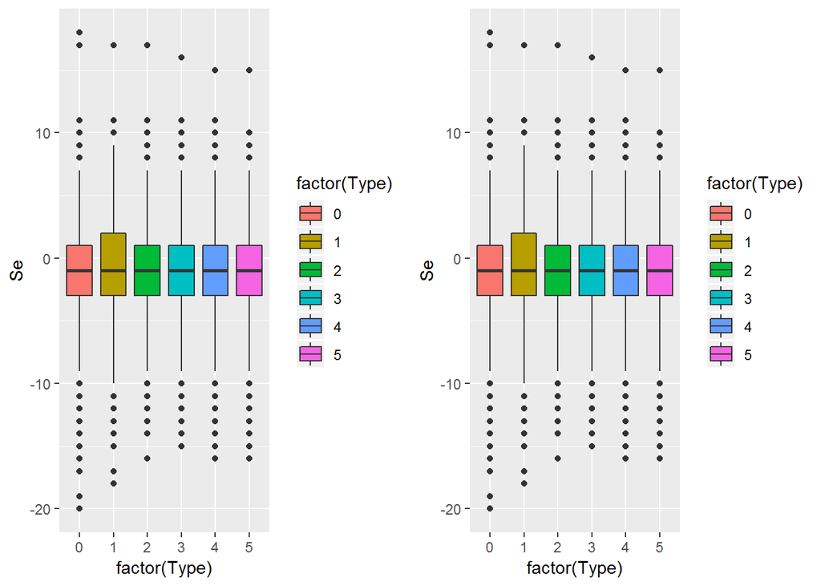

```r
b1=ggplot(DataWeather,aes(x=factor(Type), y=Se,fill=factor(Type))) + geom_boxplot();
b2=ggplot(DataWeather,aes(x=factor(Type), y=Se,fill=factor(Type))) + geom_boxplot();
grid.arrange(b1, b2, ncol=2);
```

### Compare the short & long term weather forecast accuracy

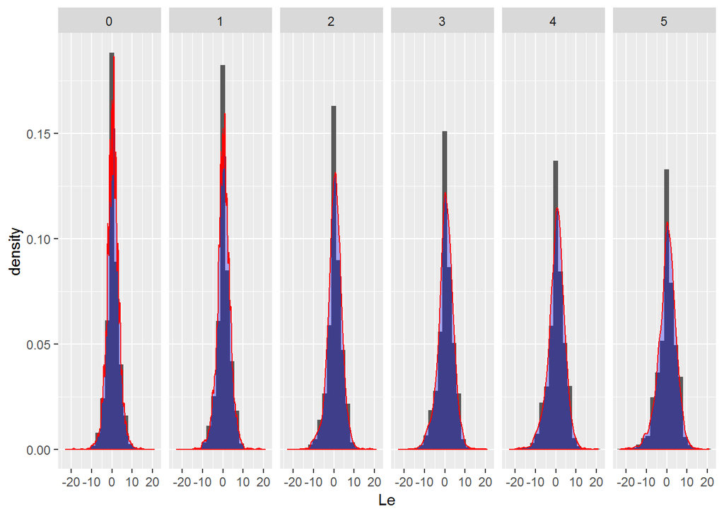

```r
ggplot(DataWeather, aes(x = Le)) +
geom_histogram(aes(y=..density..),bins = 20) +
geom_density(color='red', fill='blue',alpha=0.3)+
facet_grid(~Type);
```

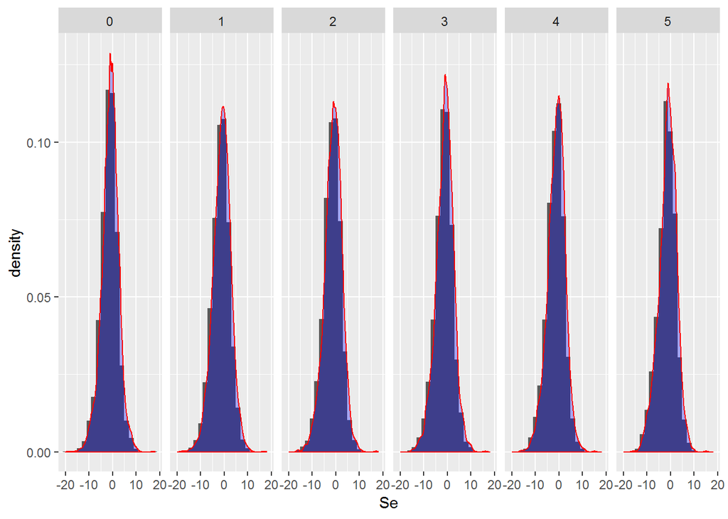

```r
ggplot(DataWeather, aes(x = Se)) +
geom_histogram(aes(y=..density..),bins = 20) +
geom_density(color='red', fill='blue',alpha=0.3)+
facet_grid(~Type);
```

### Relationship between two forecast errors

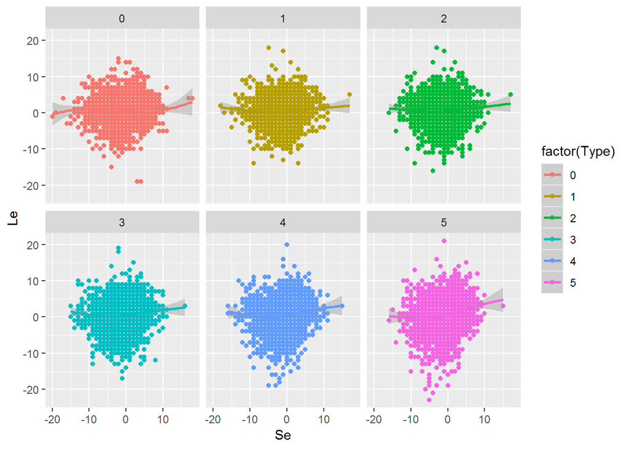

```r
ggplot(data=DataWeather,aes(x = Se, y=Le, color=factor(Type)) )+
  geom_point()+
  geom_smooth()+
  facet_wrap(~Type);
```

### Any States have smaller/larger forecast errors?

- The following graph is messy

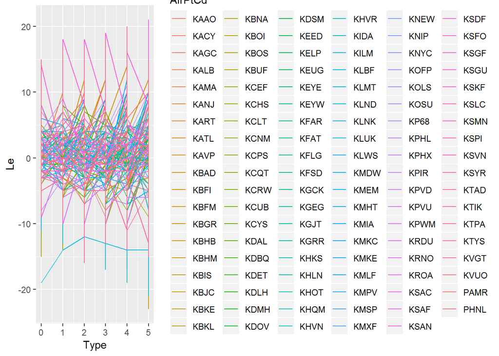

```r
ggplot(DataWeather, aes(x = Type, y = Le)) +
  geom_line(aes(color = AirPtCd ));
```

- We now aggregate the data by State

```r
Data=left_join(DataWeather,locations, by=c("AirPtCd") );
str(Data);
```

```
## 'data.frame':    22535 obs. of  16 variables:
##  $ ID               : int  1 2 3 4 5 6 7 8 9 10 ...
##  $ Date             : Date, format: "2017-08-01" "2017-08-01" ...
##  $ ForecastDate     : Date, format: "2017-07-27" "2017-07-27" ...
##  $ MaxTemp_forecast : int  72 83 80 84 84 86 80 86 84 85 ...
##  $ MinTemp_forecast : int  56 60 63 67 65 62 58 64 68 64 ...
##  $ Max_TemperatureF : int  84 87 86 80 86 90 79 89 86 87 ...
##  $ Mean_TemperatureF: int  70 72 75 74 75 78 68 72 75 75 ...
##  $ Min_TemperatureF : int  55 57 63 67 64 66 56 57 64 62 ...
##  $ AirPtCd          : Factor w/ 113 levels "KAAO","KACY",..: 14 13 89 22 87 69 74 24 57 4 ...
##  $ Type             : int  5 5 5 5 5 5 5 5 5 5 ...
##  $ Le               : int  12 4 6 -4 2 4 -1 3 2 2 ...
##  $ Se               : int  -1 -3 0 0 -1 4 -2 -7 -4 -2 ...
##  $ city             : Factor w/ 109 levels "Albany","Amarillo",..: 31 9 79 13 80 59 66 101 69 1 ...
##  $ state            : Factor w/ 50 levels "Alabama","Alaska",..: 19 19 19 21 39 29 45 21 7 32 ...
##  $ longitude        : num  -67 -68.8 -70.2 -71.1 -71.4 ...
##  $ latitude         : num  44.9 44.8 43.7 42.4 41.8 ...
```

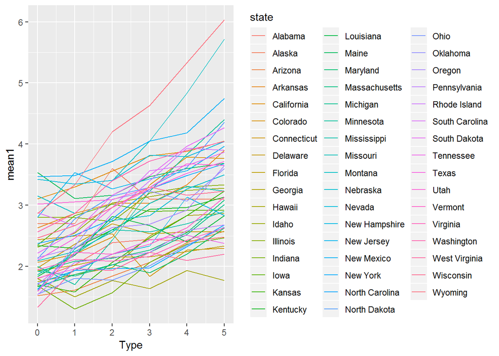

```r
##aggregate the data by Tpye and State; use the mean of the absolute forecast errors
Data=Data%>% group_by(Type, state)%>% summarise(mean1=mean(abs(Le)), mean2=mean(abs(Se)));
ggplot(Data, aes(x = Type, y = mean1)) +
  geom_line(aes(color = state ));
```

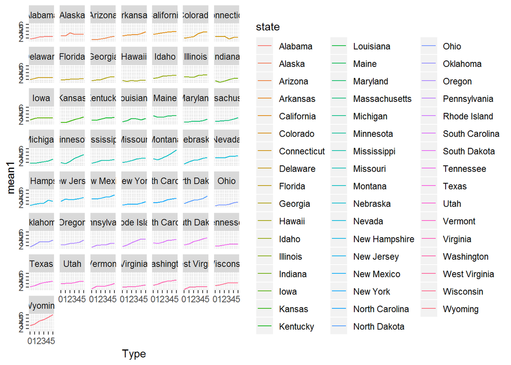

```r
ggplot(Data, aes(x = Type, y = mean1,color=state))  +
  geom_line()+
  facet_wrap(~state, ncol = 7);
```